# Intro to the Tidyverse

2024-07-29

# 1 Overview

## 1.1 Purpose

The purpose of this document is to provide an introduction into using Tidyverse in R. We will review the “core” packages within the Tidyverse and give examples.

## 1.2 Load packages

```r
package_names <- c("tidyverse", "here", "janitor", "vtable", "ggimage")

for(x in package_names){
if (!x %in% rownames(installed.packages())) install.packages(x)
}

library(tidyverse)
library(here) #is a helpful package for defining file paths
library(janitor) #is a helpful package for cleaning data
library(vtable) #is a helpful package for summarizing data
```

## 1.3 Load data

We’ll be using the Star Wars data that comes loaded with the tidyverse.

```r
starwars_data <- starwars
starwars_data
```

```
## # A tibble: 87 × 14
##    name        height  mass hair_…¹ skin_…² eye_c…³ birth…⁴ sex   gender homew…⁵
##    <chr>        <int> <dbl> <chr>   <chr>   <chr>     <dbl> <chr> <chr>  <chr>
##  1 Luke Skywa…    172    77 blond   fair    blue       19   male  mascu… Tatooi…
##  2 C-3PO          167    75 <NA>    gold    yellow    112   none  mascu… Tatooi…
##  3 R2-D2           96    32 <NA>    white,… red        33   none  mascu… Naboo
##  4 Darth Vader    202   136 none    white   yellow     41.9 male  mascu… Tatooi…
##  5 Leia Organa    150    49 brown   light   brown      19   fema… femin… Aldera…
##  6 Owen Lars      178   120 brown,… light   blue       52   male  mascu… Tatooi…
##  7 Beru White…    165    75 brown   light   blue       47   fema… femin… Tatooi…
##  8 R5-D4           97    32 <NA>    white,… red        NA   none  mascu… Tatooi…
##  9 Biggs Dark…    183    84 black   light   brown      24   male  mascu… Tatooi…
## 10 Obi-Wan Ke…    182    77 auburn… fair    blue-g…    57   male  mascu… Stewjon
## # … with 77 more rows, 4 more variables: species <chr>, films <list>,
## #   vehicles <list>, starships <list>, and abbreviated variable names
## #   ¹hair_color, ²skin_color, ³eye_color, ⁴birth_year, ⁵homeworld
```

```r
vtable(starwars_data)
```

starwars_data

| Name | Class | Values |
| --- | --- | --- |
| name | character |  |
| height | integer | Num: 66 to 264 |
| mass | numeric | Num: 15 to 1358 |
| hair_color | character |  |
| skin_color | character |  |
| eye_color | character |  |
| birth_year | numeric | Num: 8 to 896 |
| sex | character |  |
| gender | character |  |
| homeworld | character |  |
| species | character |  |
| films | list |  |
| vehicles | list |  |
| starships | list |  |

## 1.4 Tidyverse Basics

Tidyverse was created with the purpose to have more consistent and intuitive verbiage. There are several “core” packages we’ll discuss here, including:  
- Readr: read and write delimited files  
- Dplyr: manipulate data  
- Tidyr: tidy and clean data  
- Stringr: find, extract, and replace strings  
- Purrr: programming  
- Forcats: working with factors

GGplot is another major package in the tidyverse, but is not discussed here.

### 1.4.1 The Pipe %>%

The pipe operator “%>%” strings together sequences of commands.

It takes whatever is on the left side of the operator *and then* does the next command.

Example: take starwars_data *and then* rename a column, save as starwars_data2

```r
starwars_data2 <- starwars_data %>%
  rename(character_name = name)

starwars_data2
```

```
## # A tibble: 87 × 14
##    character…¹ height  mass hair_…² skin_…³ eye_c…⁴ birth…⁵ sex   gender homew…⁶
##    <chr>        <int> <dbl> <chr>   <chr>   <chr>     <dbl> <chr> <chr>  <chr>
##  1 Luke Skywa…    172    77 blond   fair    blue       19   male  mascu… Tatooi…
##  2 C-3PO          167    75 <NA>    gold    yellow    112   none  mascu… Tatooi…
##  3 R2-D2           96    32 <NA>    white,… red        33   none  mascu… Naboo
##  4 Darth Vader    202   136 none    white   yellow     41.9 male  mascu… Tatooi…
##  5 Leia Organa    150    49 brown   light   brown      19   fema… femin… Aldera…
##  6 Owen Lars      178   120 brown,… light   blue       52   male  mascu… Tatooi…
##  7 Beru White…    165    75 brown   light   blue       47   fema… femin… Tatooi…
##  8 R5-D4           97    32 <NA>    white,… red        NA   none  mascu… Tatooi…
##  9 Biggs Dark…    183    84 black   light   brown      24   male  mascu… Tatooi…
## 10 Obi-Wan Ke…    182    77 auburn… fair    blue-g…    57   male  mascu… Stewjon
## # … with 77 more rows, 4 more variables: species <chr>, films <list>,
## #   vehicles <list>, starships <list>, and abbreviated variable names
## #   ¹character_name, ²hair_color, ³skin_color, ⁴eye_color, ⁵birth_year,
## #   ⁶homeworld
```

# 2 Resources

Tidyverse website: https://www.tidyverse.org/

Learn the Tidyverse with the book R for Data Science: https://r4ds.hadley.nz/

See the different packages here: https://www.tidyverse.org/packages/

Readr cheat sheet: https://raw.githubusercontent.com/rstudio/cheatsheets/main/data-import.pdf

Dplyr cheat sheet: https://github.com/rstudio/cheatsheets/blob/main/data-transformation.pdf

Tidyr cheat sheet: https://github.com/rstudio/cheatsheets/blob/main/tidyr.pdf

Stringr cheat sheet: https://github.com/rstudio/cheatsheets/blob/main/strings.pdf

Purrr cheat sheet: https://github.com/rstudio/cheatsheets/blob/main/purrr.pdf

Forcats cheat sheet: https://raw.githubusercontent.com/rstudio/cheatsheets/main/factors.pdf

# 3 Core Packages

## 3.1 Readr

[figure not shown]

Reads rectangular data from files such as CSV

To use this as an example, we’ll write the starwars_data to CSV and read it back into R. We’ll use the package “here”, which makes it easier to define file pathways.

Since some of our columns are lists, we can’t export this to CSV without losing that data, so this is just to show an example of how to use these functions.

```r
starwars_data %>%
  write_csv(here("Tutorials",
                 "Intro_To_The_Tidyverse",
                 "starwars.csv"))

starwars_data_example <- read_csv(here("Tutorials",
                 "Intro_To_The_Tidyverse",
                 "starwars.csv"))
```

## 3.2 Dplyr

[figure not shown]

The package dplyr has functions to facilitate data manipulation using consistent verbs.

### 3.2.1 select()

Select the columns we want to keep in our data by naming the columns, the range of columns, or by description. Can also be used to rearrange the order of the columns.

For example, we can name the specific columns or range of columns that we want in the dataframe:

```r
starwars_data %>%
  select(name, hair_color)
```

```
## # A tibble: 87 × 2
##    name               hair_color
##    <chr>              <chr>
##  1 Luke Skywalker     blond
##  2 C-3PO              <NA>
##  3 R2-D2              <NA>
##  4 Darth Vader        none
##  5 Leia Organa        brown
##  6 Owen Lars          brown, grey
##  7 Beru Whitesun lars brown
##  8 R5-D4              <NA>
##  9 Biggs Darklighter  black
## 10 Obi-Wan Kenobi     auburn, white
## # … with 77 more rows
```

```r
starwars_data %>%
  select(1:3)
```

```
## # A tibble: 87 × 3
##    name               height  mass
##    <chr>               <int> <dbl>
##  1 Luke Skywalker        172    77
##  2 C-3PO                 167    75
##  3 R2-D2                  96    32
##  4 Darth Vader           202   136
##  5 Leia Organa           150    49
##  6 Owen Lars             178   120
##  7 Beru Whitesun lars    165    75
##  8 R5-D4                  97    32
##  9 Biggs Darklighter     183    84
## 10 Obi-Wan Kenobi        182    77
## # … with 77 more rows
```

We can select which columns we want by describing the columns:

```r
starwars_data %>%
  select(name, ends_with("color"))
```

```
## # A tibble: 87 × 4
##    name               hair_color    skin_color  eye_color
##    <chr>              <chr>         <chr>       <chr>
##  1 Luke Skywalker     blond         fair        blue
##  2 C-3PO              <NA>          gold        yellow
##  3 R2-D2              <NA>          white, blue red
##  4 Darth Vader        none          white       yellow
##  5 Leia Organa        brown         light       brown
##  6 Owen Lars          brown, grey   light       blue
##  7 Beru Whitesun lars brown         light       blue
##  8 R5-D4              <NA>          white, red  red
##  9 Biggs Darklighter  black         light       brown
## 10 Obi-Wan Kenobi     auburn, white fair        blue-gray
## # … with 77 more rows
```

```r
starwars_data %>%
  select(name, where(is.numeric))
```

```
## # A tibble: 87 × 4
##    name               height  mass birth_year
##    <chr>               <int> <dbl>      <dbl>
##  1 Luke Skywalker        172    77       19
##  2 C-3PO                 167    75      112
##  3 R2-D2                  96    32       33
##  4 Darth Vader           202   136       41.9
##  5 Leia Organa           150    49       19
##  6 Owen Lars             178   120       52
##  7 Beru Whitesun lars    165    75       47
##  8 R5-D4                  97    32       NA
##  9 Biggs Darklighter     183    84       24
## 10 Obi-Wan Kenobi        182    77       57
## # … with 77 more rows
```

We can also select the columns we don’t want using the same methods:

```r
starwars_data %>%
  select(!c(films, vehicles))
```

```
## # A tibble: 87 × 12
##    name        height  mass hair_…¹ skin_…² eye_c…³ birth…⁴ sex   gender homew…⁵
##    <chr>        <int> <dbl> <chr>   <chr>   <chr>     <dbl> <chr> <chr>  <chr>
##  1 Luke Skywa…    172    77 blond   fair    blue       19   male  mascu… Tatooi…
##  2 C-3PO          167    75 <NA>    gold    yellow    112   none  mascu… Tatooi…
##  3 R2-D2           96    32 <NA>    white,… red        33   none  mascu… Naboo
##  4 Darth Vader    202   136 none    white   yellow     41.9 male  mascu… Tatooi…
##  5 Leia Organa    150    49 brown   light   brown      19   fema… femin… Aldera…
##  6 Owen Lars      178   120 brown,… light   blue       52   male  mascu… Tatooi…
##  7 Beru White…    165    75 brown   light   blue       47   fema… femin… Tatooi…
##  8 R5-D4           97    32 <NA>    white,… red        NA   none  mascu… Tatooi…
##  9 Biggs Dark…    183    84 black   light   brown      24   male  mascu… Tatooi…
## 10 Obi-Wan Ke…    182    77 auburn… fair    blue-g…    57   male  mascu… Stewjon
## # … with 77 more rows, 2 more variables: species <chr>, starships <list>, and
## #   abbreviated variable names ¹hair_color, ²skin_color, ³eye_color,
## #   ⁴birth_year, ⁵homeworld
```

```r
starwars_data %>%
  select(!where(is.character))
```

```
## # A tibble: 87 × 6
##    height  mass birth_year films     vehicles  starships
##     <int> <dbl>      <dbl> <list>    <list>    <list>
##  1    172    77       19   <chr [5]> <chr [2]> <chr [2]>
##  2    167    75      112   <chr [6]> <chr [0]> <chr [0]>
##  3     96    32       33   <chr [7]> <chr [0]> <chr [0]>
##  4    202   136       41.9 <chr [4]> <chr [0]> <chr [1]>
##  5    150    49       19   <chr [5]> <chr [1]> <chr [0]>
##  6    178   120       52   <chr [3]> <chr [0]> <chr [0]>
##  7    165    75       47   <chr [3]> <chr [0]> <chr [0]>
##  8     97    32       NA   <chr [1]> <chr [0]> <chr [0]>
##  9    183    84       24   <chr [1]> <chr [0]> <chr [1]>
## 10    182    77       57   <chr [6]> <chr [1]> <chr [5]>
## # … with 77 more rows
```

And we can rearrange the order of the columns:

```r
starwars_data %>%
  select(name, homeworld, species, everything())
```

```
## # A tibble: 87 × 14
##    name       homew…¹ species height  mass hair_…² skin_…³ eye_c…⁴ birth…⁵ sex
##    <chr>      <chr>   <chr>    <int> <dbl> <chr>   <chr>   <chr>     <dbl> <chr>
##  1 Luke Skyw… Tatooi… Human      172    77 blond   fair    blue       19   male
##  2 C-3PO      Tatooi… Droid      167    75 <NA>    gold    yellow    112   none
##  3 R2-D2      Naboo   Droid       96    32 <NA>    white,… red        33   none
##  4 Darth Vad… Tatooi… Human      202   136 none    white   yellow     41.9 male
##  5 Leia Orga… Aldera… Human      150    49 brown   light   brown      19   fema…
##  6 Owen Lars  Tatooi… Human      178   120 brown,… light   blue       52   male
##  7 Beru Whit… Tatooi… Human      165    75 brown   light   blue       47   fema…
##  8 R5-D4      Tatooi… Droid       97    32 <NA>    white,… red        NA   none
##  9 Biggs Dar… Tatooi… Human      183    84 black   light   brown      24   male
## 10 Obi-Wan K… Stewjon Human      182    77 auburn… fair    blue-g…    57   male
## # … with 77 more rows, 4 more variables: gender <chr>, films <list>,
## #   vehicles <list>, starships <list>, and abbreviated variable names
## #   ¹homeworld, ²hair_color, ³skin_color, ⁴eye_color, ⁵birth_year
```

### 3.2.2 filter()

Allows us to filter the data:

```r
starwars_data %>%
  filter(species == "Droid")
```

```
## # A tibble: 6 × 14
##   name   height  mass hair_color skin_color eye_c…¹ birth…² sex   gender homew…³
##   <chr>   <int> <dbl> <chr>      <chr>      <chr>     <dbl> <chr> <chr>  <chr>
## 1 C-3PO     167    75 <NA>       gold       yellow      112 none  mascu… Tatooi…
## 2 R2-D2      96    32 <NA>       white, bl… red          33 none  mascu… Naboo
## 3 R5-D4      97    32 <NA>       white, red red          NA none  mascu… Tatooi…
## 4 IG-88     200   140 none       metal      red          15 none  mascu… <NA>
## 5 R4-P17     96    NA none       silver, r… red, b…      NA none  femin… <NA>
## 6 BB8        NA    NA none       none       black        NA none  mascu… <NA>
## # … with 4 more variables: species <chr>, films <list>, vehicles <list>,
## #   starships <list>, and abbreviated variable names ¹eye_color, ²birth_year,
## #   ³homeworld
```

```r
starwars_data %>%
  filter(grepl("Skywalker", name))
```

```
## # A tibble: 3 × 14
##   name         height  mass hair_…¹ skin_…² eye_c…³ birth…⁴ sex   gender homew…⁵
##   <chr>         <int> <dbl> <chr>   <chr>   <chr>     <dbl> <chr> <chr>  <chr>
## 1 Luke Skywal…    172    77 blond   fair    blue       19   male  mascu… Tatooi…
## 2 Anakin Skyw…    188    84 blond   fair    blue       41.9 male  mascu… Tatooi…
## 3 Shmi Skywal…    163    NA black   fair    brown      72   fema… femin… Tatooi…
## # … with 4 more variables: species <chr>, films <list>, vehicles <list>,
## #   starships <list>, and abbreviated variable names ¹hair_color, ²skin_color,
## #   ³eye_color, ⁴birth_year, ⁵homeworld
```

```r
starwars_data %>%
  filter(species == "Human" & homeworld == "Tatooine")
```

```
## # A tibble: 8 × 14
##   name         height  mass hair_…¹ skin_…² eye_c…³ birth…⁴ sex   gender homew…⁵
##   <chr>         <int> <dbl> <chr>   <chr>   <chr>     <dbl> <chr> <chr>  <chr>
## 1 Luke Skywal…    172    77 blond   fair    blue       19   male  mascu… Tatooi…
## 2 Darth Vader     202   136 none    white   yellow     41.9 male  mascu… Tatooi…
## 3 Owen Lars       178   120 brown,… light   blue       52   male  mascu… Tatooi…
## 4 Beru Whites…    165    75 brown   light   blue       47   fema… femin… Tatooi…
## 5 Biggs Darkl…    183    84 black   light   brown      24   male  mascu… Tatooi…
## 6 Anakin Skyw…    188    84 blond   fair    blue       41.9 male  mascu… Tatooi…
## 7 Shmi Skywal…    163    NA black   fair    brown      72   fema… femin… Tatooi…
## 8 Cliegg Lars     183    NA brown   fair    blue       82   male  mascu… Tatooi…
## # … with 4 more variables: species <chr>, films <list>, vehicles <list>,
## #   starships <list>, and abbreviated variable names ¹hair_color, ²skin_color,
## #   ³eye_color, ⁴birth_year, ⁵homeworld
```

### 3.2.3 mutate()

Mutate creates new columns based on the given commands or calculations.

For example, we can create a new column, “bmi” using mass and height data:

```r
starwars_data %>%
  mutate(name, bmi = mass / ((height / 100)  ^ 2)) %>%
  select(name:mass, bmi)
```

```
## # A tibble: 87 × 4
##    name               height  mass   bmi
##    <chr>               <int> <dbl> <dbl>
##  1 Luke Skywalker        172    77  26.0
##  2 C-3PO                 167    75  26.9
##  3 R2-D2                  96    32  34.7
##  4 Darth Vader           202   136  33.3
##  5 Leia Organa           150    49  21.8
##  6 Owen Lars             178   120  37.9
##  7 Beru Whitesun lars    165    75  27.5
##  8 R5-D4                  97    32  34.0
##  9 Biggs Darklighter     183    84  25.1
## 10 Obi-Wan Kenobi        182    77  23.2
## # … with 77 more rows
```

Or we could create categories of heights:

```r
starwars_data %>%
  mutate(height_bin = case_when(height < 150 ~ "Less than 150",
                                height >= 150 & height < 175 ~ "150-174",
                                height >= 175 & height < 200 ~ "175-199",
                                height >= 200 ~ "200+")) %>%
  select(name, height, height_bin)
```

```
## # A tibble: 87 × 3
##    name               height height_bin
##    <chr>               <int> <chr>
##  1 Luke Skywalker        172 150-174
##  2 C-3PO                 167 150-174
##  3 R2-D2                  96 Less than 150
##  4 Darth Vader           202 200+
##  5 Leia Organa           150 150-174
##  6 Owen Lars             178 175-199
##  7 Beru Whitesun lars    165 150-174
##  8 R5-D4                  97 Less than 150
##  9 Biggs Darklighter     183 175-199
## 10 Obi-Wan Kenobi        182 175-199
## # … with 77 more rows
```

### 3.2.4 summarise() and arrange()

Summarise allows us to get a summarized dataframe based on the groups defined and the functions used to summarise.

For example, let’s find out how many characters there are from each species.

1. We can first use the group_by() function to group by species.
2. Then, we can use summarise(). This creates a new column (similarly to mutate) with the commands used within the arguments (in this case, it creates the column “count” using the function n()).
3. While mutate maintains all rows, summarise only maintains rows unique to the groups (in this case, species) and aggregates to the group level.
4. The arrange() function lets us see the top species first

```r
starwars %>%
  group_by(species) %>%
  summarise(count = n()) %>%
  arrange(desc(count))
```

```
## # A tibble: 38 × 2
##    species  count
##    <chr>    <int>
##  1 Human       35
##  2 Droid        6
##  3 <NA>         4
##  4 Gungan       3
##  5 Kaminoan     2
##  6 Mirialan     2
##  7 Twi'lek      2
##  8 Wookiee      2
##  9 Zabrak       2
## 10 Aleena       1
## # … with 28 more rows
```

### 3.2.5 joins

We can join data a few different ways:

A inner_join() keeps only all observations in both x and y.

A left_join() keeps all observations in x.

A right_join() keeps all observations in y.

A full_join() keeps all observations in x and y.

Here are some example data that we can join to our starwars_data. “droids” shows the number of films each droid was present in. “droids_example” is the same as “droids”, but has an additional “fake” droid added for example purposes.

```r
droids
```

```
## # A tibble: 6 × 2
##   name   no_films
##   <chr>     <int>
## 1 BB8           1
## 2 C-3PO         6
## 3 IG-88         1
## 4 R2-D2         7
## 5 R4-P17        2
## 6 R5-D4         1
```

```r
droids_example
```

```
## # A tibble: 7 × 2
##   name               no_films
##   <chr>              <chr>
## 1 BB8                1
## 2 C-3PO              6
## 3 IG-88              1
## 4 R2-D2              7
## 5 R4-P17             2
## 6 R5-D4              1
## 7 Fake Droid Example 0
```

Let’s start with an inner_join() between the starwars_data (x) and droids_example (y). As you can see, it only keeps rows in both dataframes.

```r
innerjoin <- inner_join(starwars_data, droids_example)

innerjoin
```

```
## # A tibble: 6 × 15
##   name   height  mass hair_color skin_color eye_c…¹ birth…² sex   gender homew…³
##   <chr>   <int> <dbl> <chr>      <chr>      <chr>     <dbl> <chr> <chr>  <chr>
## 1 C-3PO     167    75 <NA>       gold       yellow      112 none  mascu… Tatooi…
## 2 R2-D2      96    32 <NA>       white, bl… red          33 none  mascu… Naboo
## 3 R5-D4      97    32 <NA>       white, red red          NA none  mascu… Tatooi…
## 4 IG-88     200   140 none       metal      red          15 none  mascu… <NA>
## 5 R4-P17     96    NA none       silver, r… red, b…      NA none  femin… <NA>
## 6 BB8        NA    NA none       none       black        NA none  mascu… <NA>
## # … with 5 more variables: species <chr>, films <list>, vehicles <list>,
## #   starships <list>, no_films <chr>, and abbreviated variable names
## #   ¹eye_color, ²birth_year, ³homeworld
```

Let’s do a left_join() next with the starwars_data (x) and droids_example (y). Since starwars_data is on the left (x), we maintain all 87 rows and the new column “no_films” in our droids data (y) gets added to our data for the droids. The data for the fake droid in droids_examples does not stay in the data because it does not have a match in starwars_data.

```r
leftjoin <- left_join(starwars_data, droids_example) %>%
  select(name, no_films, everything())

leftjoin
```

```
## # A tibble: 87 × 15
##    name        no_fi…¹ height  mass hair_…² skin_…³ eye_c…⁴ birth…⁵ sex   gender
##    <chr>       <chr>    <int> <dbl> <chr>   <chr>   <chr>     <dbl> <chr> <chr>
##  1 Luke Skywa… <NA>       172    77 blond   fair    blue       19   male  mascu…
##  2 C-3PO       6          167    75 <NA>    gold    yellow    112   none  mascu…
##  3 R2-D2       7           96    32 <NA>    white,… red        33   none  mascu…
##  4 Darth Vader <NA>       202   136 none    white   yellow     41.9 male  mascu…
##  5 Leia Organa <NA>       150    49 brown   light   brown      19   fema… femin…
##  6 Owen Lars   <NA>       178   120 brown,… light   blue       52   male  mascu…
##  7 Beru White… <NA>       165    75 brown   light   blue       47   fema… femin…
##  8 R5-D4       1           97    32 <NA>    white,… red        NA   none  mascu…
##  9 Biggs Dark… <NA>       183    84 black   light   brown      24   male  mascu…
## 10 Obi-Wan Ke… <NA>       182    77 auburn… fair    blue-g…    57   male  mascu…
## # … with 77 more rows, 5 more variables: homeworld <chr>, species <chr>,
## #   films <list>, vehicles <list>, starships <list>, and abbreviated variable
## #   names ¹no_films, ²hair_color, ³skin_color, ⁴eye_color, ⁵birth_year
```

Next, a right_join(). This will keep all observations in droids_example, including the data for the fake droid. All the columns from starwars_data for those droids gets added to the data.

```r
rightjoin <- right_join(starwars_data, droids_example) %>%
  select(name, no_films, everything())

rightjoin
```

```
## # A tibble: 7 × 15
##   name         no_fi…¹ height  mass hair_…² skin_…³ eye_c…⁴ birth…⁵ sex   gender
##   <chr>        <chr>    <int> <dbl> <chr>   <chr>   <chr>     <dbl> <chr> <chr>
## 1 C-3PO        6          167    75 <NA>    gold    yellow      112 none  mascu…
## 2 R2-D2        7           96    32 <NA>    white,… red          33 none  mascu…
## 3 R5-D4        1           97    32 <NA>    white,… red          NA none  mascu…
## 4 IG-88        1          200   140 none    metal   red          15 none  mascu…
## 5 R4-P17       2           96    NA none    silver… red, b…      NA none  femin…
## 6 BB8          1           NA    NA none    none    black        NA none  mascu…
## 7 Fake Droid … 0           NA    NA <NA>    <NA>    <NA>         NA <NA>  <NA>
## # … with 5 more variables: homeworld <chr>, species <chr>, films <list>,
## #   vehicles <list>, starships <list>, and abbreviated variable names
## #   ¹no_films, ²hair_color, ³skin_color, ⁴eye_color, ⁵birth_year
```

Last, we’ll do a full_join(), where all observations present in either dataframe will be joined.

This includes the fake droid data along with the observations for all non-droids.

```r
fulljoin <- full_join(starwars_data, droids_example) %>%
  select(name, no_films, everything()) %>%
  arrange(no_films)


fulljoin
```

```
## # A tibble: 88 × 15
##    name        no_fi…¹ height  mass hair_…² skin_…³ eye_c…⁴ birth…⁵ sex   gender
##    <chr>       <chr>    <int> <dbl> <chr>   <chr>   <chr>     <dbl> <chr> <chr>
##  1 Fake Droid… 0           NA    NA <NA>    <NA>    <NA>       NA   <NA>  <NA>
##  2 R5-D4       1           97    32 <NA>    white,… red        NA   none  mascu…
##  3 IG-88       1          200   140 none    metal   red        15   none  mascu…
##  4 BB8         1           NA    NA none    none    black      NA   none  mascu…
##  5 R4-P17      2           96    NA none    silver… red, b…    NA   none  femin…
##  6 C-3PO       6          167    75 <NA>    gold    yellow    112   none  mascu…
##  7 R2-D2       7           96    32 <NA>    white,… red        33   none  mascu…
##  8 Luke Skywa… <NA>       172    77 blond   fair    blue       19   male  mascu…
##  9 Darth Vader <NA>       202   136 none    white   yellow     41.9 male  mascu…
## 10 Leia Organa <NA>       150    49 brown   light   brown      19   fema… femin…
## # … with 78 more rows, 5 more variables: homeworld <chr>, species <chr>,
## #   films <list>, vehicles <list>, starships <list>, and abbreviated variable
## #   names ¹no_films, ²hair_color, ³skin_color, ⁴eye_color, ⁵birth_year
```

## 3.3 Tidyr

[figure not shown]

The package tidyr has functions that help achieve “tidy” data:  
- Each variable is a column; each column is a variable  
- Each observation is a row; each row is an observation  
- Each value is a cell; each cell is a single value

### 3.3.1 nest() and unnest()

We can nest or unnest data using these functions.

For example, we could nest all the data columns by a group:

```r
starwars_data_nest <- starwars_data %>%
  group_by(gender) %>%
  nest()

starwars_data_nest
```

```
## # A tibble: 3 × 2
## # Groups:   gender [3]
##   gender    data
##   <chr>     <list>
## 1 masculine <tibble [66 × 13]>
## 2 feminine  <tibble [17 × 13]>
## 3 <NA>      <tibble [4 × 13]>
```

And then we could use pluck() to grab the data separately for each of the groups.

```r
starwars_data_nest %>%
  pluck("data")
```

```
## [[1]]
## # A tibble: 66 × 13
##    name       height  mass hair_…¹ skin_…² eye_c…³ birth…⁴ sex   homew…⁵ species
##    <chr>       <int> <dbl> <chr>   <chr>   <chr>     <dbl> <chr> <chr>   <chr>
##  1 Luke Skyw…    172    77 blond   fair    blue       19   male  Tatooi… Human
##  2 C-3PO         167    75 <NA>    gold    yellow    112   none  Tatooi… Droid
##  3 R2-D2          96    32 <NA>    white,… red        33   none  Naboo   Droid
##  4 Darth Vad…    202   136 none    white   yellow     41.9 male  Tatooi… Human
##  5 Owen Lars     178   120 brown,… light   blue       52   male  Tatooi… Human
##  6 R5-D4          97    32 <NA>    white,… red        NA   none  Tatooi… Droid
##  7 Biggs Dar…    183    84 black   light   brown      24   male  Tatooi… Human
##  8 Obi-Wan K…    182    77 auburn… fair    blue-g…    57   male  Stewjon Human
##  9 Anakin Sk…    188    84 blond   fair    blue       41.9 male  Tatooi… Human
## 10 Wilhuff T…    180    NA auburn… fair    blue       64   male  Eriadu  Human
## # … with 56 more rows, 3 more variables: films <list>, vehicles <list>,
## #   starships <list>, and abbreviated variable names ¹hair_color, ²skin_color,
## #   ³eye_color, ⁴birth_year, ⁵homeworld
##
## [[2]]
## # A tibble: 17 × 13
##    name       height  mass hair_…¹ skin_…² eye_c…³ birth…⁴ sex   homew…⁵ species
##    <chr>       <int> <dbl> <chr>   <chr>   <chr>     <dbl> <chr> <chr>   <chr>
##  1 Leia Orga…    150  49   brown   light   brown        19 fema… Aldera… Human
##  2 Beru Whit…    165  75   brown   light   blue         47 fema… Tatooi… Human
##  3 Mon Mothma    150  NA   auburn  fair    blue         48 fema… Chandr… Human
##  4 Shmi Skyw…    163  NA   black   fair    brown        72 fema… Tatooi… Human
##  5 Ayla Secu…    178  55   none    blue    hazel        48 fema… Ryloth  Twi'lek
##  6 Adi Gallia    184  50   none    dark    blue         NA fema… Corusc… Tholot…
##  7 Cordé         157  NA   brown   light   brown        NA fema… Naboo   Human
##  8 Luminara …    170  56.2 black   yellow  blue         58 fema… Mirial  Mirial…
##  9 Barriss O…    166  50   black   yellow  blue         40 fema… Mirial  Mirial…
## 10 Dormé         165  NA   brown   light   brown        NA fema… Naboo   Human
## 11 Zam Wesell    168  55   blonde  fair, … yellow       NA fema… Zolan   Clawdi…
## 12 Taun We       213  NA   none    grey    black        NA fema… Kamino  Kamino…
## 13 Jocasta Nu    167  NA   white   fair    blue         NA fema… Corusc… Human
## 14 R4-P17         96  NA   none    silver… red, b…      NA none  <NA>    Droid
## 15 Shaak Ti      178  57   none    red, b… black        NA fema… Shili   Togruta
## 16 Rey            NA  NA   brown   light   hazel        NA fema… <NA>    Human
## 17 Padmé Ami…    165  45   brown   light   brown        46 fema… Naboo   Human
## # … with 3 more variables: films <list>, vehicles <list>, starships <list>, and
## #   abbreviated variable names ¹hair_color, ²skin_color, ³eye_color,
## #   ⁴birth_year, ⁵homeworld
##
## [[3]]
## # A tibble: 4 × 13
##   name  height  mass hair_…¹ skin_…² eye_c…³ birth…⁴ sex   homew…⁵ species films
##   <chr>  <int> <dbl> <chr>   <chr>   <chr>     <dbl> <chr> <chr>   <chr>   <lis>
## 1 Ric …    183    NA brown   fair    blue         NA <NA>  Naboo   <NA>    <chr>
## 2 Quar…    183    NA black   dark    brown        62 <NA>  Naboo   <NA>    <chr>
## 3 Sly …    178    48 none    pale    white        NA <NA>  Umbara  <NA>    <chr>
## 4 Capt…     NA    NA unknown unknown unknown      NA <NA>  <NA>    <NA>    <chr>
## # … with 2 more variables: vehicles <list>, starships <list>, and abbreviated
## #   variable names ¹hair_color, ²skin_color, ³eye_color, ⁴birth_year,
## #   ⁵homeworld
```

Next, we will unnest some data. As a reminder, the Star Wars data has 3 columns stored as lists:

```r
starwars_data %>%
  select(where(is.list))
```

```
## # A tibble: 87 × 3
##    films     vehicles  starships
##    <list>    <list>    <list>
##  1 <chr [5]> <chr [2]> <chr [2]>
##  2 <chr [6]> <chr [0]> <chr [0]>
##  3 <chr [7]> <chr [0]> <chr [0]>
##  4 <chr [4]> <chr [0]> <chr [1]>
##  5 <chr [5]> <chr [1]> <chr [0]>
##  6 <chr [3]> <chr [0]> <chr [0]>
##  7 <chr [3]> <chr [0]> <chr [0]>
##  8 <chr [1]> <chr [0]> <chr [0]>
##  9 <chr [1]> <chr [0]> <chr [1]>
## 10 <chr [6]> <chr [1]> <chr [5]>
## # … with 77 more rows
```

Let’s unnest the data in the films field (stored as a list)

We can do this using unnest_longer()

```r
starwars_data2 <- starwars_data %>%
  select(films, name) %>%
  unnest_longer(films)

starwars_data2
```

```
## # A tibble: 173 × 2
##    films                   name
##    <chr>                   <chr>
##  1 The Empire Strikes Back Luke Skywalker
##  2 Revenge of the Sith     Luke Skywalker
##  3 Return of the Jedi      Luke Skywalker
##  4 A New Hope              Luke Skywalker
##  5 The Force Awakens       Luke Skywalker
##  6 The Empire Strikes Back C-3PO
##  7 Attack of the Clones    C-3PO
##  8 The Phantom Menace      C-3PO
##  9 Revenge of the Sith     C-3PO
## 10 Return of the Jedi      C-3PO
## # … with 163 more rows
```

Or using unnest_wider()

```r
starwars_data %>%
  select(name, films) %>%
  unnest_wider(films, names_sep = "_")
```

```
## # A tibble: 87 × 8
##    name               films_1    films_2 films_3 films_4 films_5 films_6 films_7
##    <chr>              <chr>      <chr>   <chr>   <chr>   <chr>   <chr>   <chr>
##  1 Luke Skywalker     The Empir… Reveng… Return… A New … The Fo… <NA>    <NA>
##  2 C-3PO              The Empir… Attack… The Ph… Reveng… Return… A New … <NA>
##  3 R2-D2              The Empir… Attack… The Ph… Reveng… Return… A New … The Fo…
##  4 Darth Vader        The Empir… Reveng… Return… A New … <NA>    <NA>    <NA>
##  5 Leia Organa        The Empir… Reveng… Return… A New … The Fo… <NA>    <NA>
##  6 Owen Lars          Attack of… Reveng… A New … <NA>    <NA>    <NA>    <NA>
##  7 Beru Whitesun lars Attack of… Reveng… A New … <NA>    <NA>    <NA>    <NA>
##  8 R5-D4              A New Hope <NA>    <NA>    <NA>    <NA>    <NA>    <NA>
##  9 Biggs Darklighter  A New Hope <NA>    <NA>    <NA>    <NA>    <NA>    <NA>
## 10 Obi-Wan Kenobi     The Empir… Attack… The Ph… Reveng… Return… A New … <NA>
## # … with 77 more rows
```

### 3.3.2 pivot_longer() & pivot_wider()

Let’s play around some more with transforming data. First, we’ll do something similar to what we did above but now using the pivot functions.

Let’s work with the newly unnested (using unnest_longer) field “films” to pivot our data to see which characters are in which films.

First, we’ll start by pivoting wider.

```r
starwars_data_wide <- starwars_data2 %>%
  mutate(in_movie = 1) %>%
  pivot_wider(names_from = films,
              values_from = in_movie)
starwars_data_wide
```

```
## # A tibble: 87 × 8
##    name               The Empi…¹ Reven…² Retur…³ A New…⁴ The F…⁵ Attac…⁶ The P…⁷
##    <chr>                   <dbl>   <dbl>   <dbl>   <dbl>   <dbl>   <dbl>   <dbl>
##  1 Luke Skywalker              1       1       1       1       1      NA      NA
##  2 C-3PO                       1       1       1       1      NA       1       1
##  3 R2-D2                       1       1       1       1       1       1       1
##  4 Darth Vader                 1       1       1       1      NA      NA      NA
##  5 Leia Organa                 1       1       1       1       1      NA      NA
##  6 Owen Lars                  NA       1      NA       1      NA       1      NA
##  7 Beru Whitesun lars         NA       1      NA       1      NA       1      NA
##  8 R5-D4                      NA      NA      NA       1      NA      NA      NA
##  9 Biggs Darklighter          NA      NA      NA       1      NA      NA      NA
## 10 Obi-Wan Kenobi              1       1       1       1      NA       1       1
## # … with 77 more rows, and abbreviated variable names
## #   ¹`The Empire Strikes Back`, ²`Revenge of the Sith`, ³`Return of the Jedi`,
## #   ⁴`A New Hope`, ⁵`The Force Awakens`, ⁶`Attack of the Clones`,
## #   ⁷`The Phantom Menace`
```

We can use the janitor package to clean up the new column names in one line of code

```r
starwars_data_wide2 <- janitor::clean_names(starwars_data_wide)
starwars_data_wide2
```

```
## # A tibble: 87 × 8
##    name               the_empi…¹ reven…² retur…³ a_new…⁴ the_f…⁵ attac…⁶ the_p…⁷
##    <chr>                   <dbl>   <dbl>   <dbl>   <dbl>   <dbl>   <dbl>   <dbl>
##  1 Luke Skywalker              1       1       1       1       1      NA      NA
##  2 C-3PO                       1       1       1       1      NA       1       1
##  3 R2-D2                       1       1       1       1       1       1       1
##  4 Darth Vader                 1       1       1       1      NA      NA      NA
##  5 Leia Organa                 1       1       1       1       1      NA      NA
##  6 Owen Lars                  NA       1      NA       1      NA       1      NA
##  7 Beru Whitesun lars         NA       1      NA       1      NA       1      NA
##  8 R5-D4                      NA      NA      NA       1      NA      NA      NA
##  9 Biggs Darklighter          NA      NA      NA       1      NA      NA      NA
## 10 Obi-Wan Kenobi              1       1       1       1      NA       1       1
## # … with 77 more rows, and abbreviated variable names ¹the_empire_strikes_back,
## #   ²revenge_of_the_sith, ³return_of_the_jedi, ⁴a_new_hope, ⁵the_force_awakens,
## #   ⁶attack_of_the_clones, ⁷the_phantom_menace
```

And we can replace those NAs with 0s where the character is not in the movie by using the mutate() function.

```r
starwars_data_wide2.2 <- starwars_data_wide2 %>%
  mutate(across(the_empire_strikes_back:the_phantom_menace, ~ replace_na(.x, 0)))
starwars_data_wide2.2
```

```
## # A tibble: 87 × 8
##    name               the_empi…¹ reven…² retur…³ a_new…⁴ the_f…⁵ attac…⁶ the_p…⁷
##    <chr>                   <dbl>   <dbl>   <dbl>   <dbl>   <dbl>   <dbl>   <dbl>
##  1 Luke Skywalker              1       1       1       1       1       0       0
##  2 C-3PO                       1       1       1       1       0       1       1
##  3 R2-D2                       1       1       1       1       1       1       1
##  4 Darth Vader                 1       1       1       1       0       0       0
##  5 Leia Organa                 1       1       1       1       1       0       0
##  6 Owen Lars                   0       1       0       1       0       1       0
##  7 Beru Whitesun lars          0       1       0       1       0       1       0
##  8 R5-D4                       0       0       0       1       0       0       0
##  9 Biggs Darklighter           0       0       0       1       0       0       0
## 10 Obi-Wan Kenobi              1       1       1       1       0       1       1
## # … with 77 more rows, and abbreviated variable names ¹the_empire_strikes_back,
## #   ²revenge_of_the_sith, ³return_of_the_jedi, ⁴a_new_hope, ⁵the_force_awakens,
## #   ⁶attack_of_the_clones, ⁷the_phantom_menace
```

Then we can pivot this longer again…

```r
starwars_data_long <- starwars_data_wide2.2 %>%
  pivot_longer(cols = the_empire_strikes_back:the_phantom_menace,
               names_to = "movie",
               values_to = "character_in_movie")
starwars_data_long
```

```
## # A tibble: 609 × 3
##    name           movie                   character_in_movie
##    <chr>          <chr>                                <dbl>
##  1 Luke Skywalker the_empire_strikes_back                  1
##  2 Luke Skywalker revenge_of_the_sith                      1
##  3 Luke Skywalker return_of_the_jedi                       1
##  4 Luke Skywalker a_new_hope                               1
##  5 Luke Skywalker the_force_awakens                        1
##  6 Luke Skywalker attack_of_the_clones                     0
##  7 Luke Skywalker the_phantom_menace                       0
##  8 C-3PO          the_empire_strikes_back                  1
##  9 C-3PO          revenge_of_the_sith                      1
## 10 C-3PO          return_of_the_jedi                       1
## # … with 599 more rows
```

And we did this in separate chunks, but the pipe could have done it all in one chunk of code:

```r
starwars_data_together <- starwars_data %>%
  select(films, name) %>%
  unnest_longer(films) %>%
  mutate(in_movie = 1) %>%
  pivot_wider(names_from = films,
              values_from = in_movie) %>%
  clean_names() %>%
  mutate(across(the_empire_strikes_back:the_phantom_menace, ~ replace_na(.x, 0)))
```

### 3.3.3 unite() and separate()

Maybe we want to combine the film name with the episode number. We could do this using unite().

First, we’ll set up our data for this. We’ll unnest the films column, select only the columns we need, and will create a column (using mutate) with those episode numbers. We can use case_when() to do this.

```r
starwars_data_unite <- starwars_data %>%
  unnest(films) %>%
  select(name, films) %>%
  mutate(episode_no = case_when(films == "The Phantom Menace" ~ 1,
                         films == "Attack of the Clones" ~ 2,
                         films == "Revenge of the Sith" ~ 3,
                         films == "A New Hope" ~ 4,
                         films == "The Empire Strikes Back" ~ 5,
                         films == "Return of the Jedi" ~ 6,
                         films == "The Force Awakens" ~ 7))

starwars_data_unite
```

```
## # A tibble: 173 × 3
##    name           films                   episode_no
##    <chr>          <chr>                        <dbl>
##  1 Luke Skywalker The Empire Strikes Back          5
##  2 Luke Skywalker Revenge of the Sith              3
##  3 Luke Skywalker Return of the Jedi               6
##  4 Luke Skywalker A New Hope                       4
##  5 Luke Skywalker The Force Awakens                7
##  6 C-3PO          The Empire Strikes Back          5
##  7 C-3PO          Attack of the Clones             2
##  8 C-3PO          The Phantom Menace               1
##  9 C-3PO          Revenge of the Sith              3
## 10 C-3PO          Return of the Jedi               6
## # … with 163 more rows
```

Now we can unite those two columns using unite().

The arguments in unite are:  
- The new column name you are creating. In this case, we’ll call it “movie”  
- The columns you are uniting (episode_no and films)  
- The string that will separate the two combined fields (“:”)  
- You can also include remove = TRUE or remove = FALSE to keep or remove original columns

```r
starwars_data_unite2 <- starwars_data_unite %>%
  unite("movie", c(episode_no, films), sep = ": ")

starwars_data_unite2
```

```
## # A tibble: 173 × 2
##    name           movie
##    <chr>          <chr>
##  1 Luke Skywalker 5: The Empire Strikes Back
##  2 Luke Skywalker 3: Revenge of the Sith
##  3 Luke Skywalker 6: Return of the Jedi
##  4 Luke Skywalker 4: A New Hope
##  5 Luke Skywalker 7: The Force Awakens
##  6 C-3PO          5: The Empire Strikes Back
##  7 C-3PO          2: Attack of the Clones
##  8 C-3PO          1: The Phantom Menace
##  9 C-3PO          3: Revenge of the Sith
## 10 C-3PO          6: Return of the Jedi
## # … with 163 more rows
```

We can separate these columns again using separate()

```r
starwars_data_unite2 %>%
  separate(movie, into = c("episode_no", "films"), sep = ": ")
```

```
## # A tibble: 173 × 3
##    name           episode_no films
##    <chr>          <chr>      <chr>
##  1 Luke Skywalker 5          The Empire Strikes Back
##  2 Luke Skywalker 3          Revenge of the Sith
##  3 Luke Skywalker 6          Return of the Jedi
##  4 Luke Skywalker 4          A New Hope
##  5 Luke Skywalker 7          The Force Awakens
##  6 C-3PO          5          The Empire Strikes Back
##  7 C-3PO          2          Attack of the Clones
##  8 C-3PO          1          The Phantom Menace
##  9 C-3PO          3          Revenge of the Sith
## 10 C-3PO          6          Return of the Jedi
## # … with 163 more rows
```

## 3.4 Stringr

[figure not shown]

Makes working with strings “as easy as possible”. Find/replace/extract strings using various functions. You can use these with regular expressions (RegEx)

### 3.4.1 str_detect()

Tells you if there is a match to the specified pattern.

```r
starwars_data %>%
  filter(str_detect(hair_color, "brown"))
```

```
## # A tibble: 19 × 14
##    name        height  mass hair_…¹ skin_…² eye_c…³ birth…⁴ sex   gender homew…⁵
##    <chr>        <int> <dbl> <chr>   <chr>   <chr>     <dbl> <chr> <chr>  <chr>
##  1 Leia Organa    150    49 brown   light   brown        19 fema… femin… Aldera…
##  2 Owen Lars      178   120 brown,… light   blue         52 male  mascu… Tatooi…
##  3 Beru White…    165    75 brown   light   blue         47 fema… femin… Tatooi…
##  4 Chewbacca      228   112 brown   unknown blue        200 male  mascu… Kashyy…
##  5 Han Solo       180    80 brown   fair    brown        29 male  mascu… Corell…
##  6 Wedge Anti…    170    77 brown   fair    hazel        21 male  mascu… Corell…
##  7 Jek Tono P…    180   110 brown   fair    blue         NA male  mascu… Bestin…
##  8 Arvel Cryn…     NA    NA brown   fair    brown        NA male  mascu… <NA>
##  9 Wicket Sys…     88    20 brown   brown   brown         8 male  mascu… Endor
## 10 Qui-Gon Ji…    193    89 brown   fair    blue         92 male  mascu… <NA>
## 11 Ric Olié       183    NA brown   fair    blue         NA <NA>  <NA>   Naboo
## 12 Cordé          157    NA brown   light   brown        NA fema… femin… Naboo
## 13 Cliegg Lars    183    NA brown   fair    blue         82 male  mascu… Tatooi…
## 14 Dormé          165    NA brown   light   brown        NA fema… femin… Naboo
## 15 Tarfful        234   136 brown   brown   blue         NA male  mascu… Kashyy…
## 16 Raymus Ant…    188    79 brown   light   brown        NA male  mascu… Aldera…
## 17 Rey             NA    NA brown   light   hazel        NA fema… femin… <NA>
## 18 Poe Dameron     NA    NA brown   light   brown        NA male  mascu… <NA>
## 19 Padmé Amid…    165    45 brown   light   brown        46 fema… femin… Naboo
## # … with 4 more variables: species <chr>, films <list>, vehicles <list>,
## #   starships <list>, and abbreviated variable names ¹hair_color, ²skin_color,
## #   ³eye_color, ⁴birth_year, ⁵homeworld
```

We can also use regular expressions. More information can be found in the stringr cheat sheet linked at the top of the page, but here’s a quick example. This will look at the character’s name in the row and create a new column with TRUE if there are any digits in the name and FALSE if there are no digits in the name.

```r
starwars_data %>%
  mutate(name_digit = str_detect(name, "[:digit:]")) %>%
  select(name, name_digit)
```

```
## # A tibble: 87 × 2
##    name               name_digit
##    <chr>              <lgl>
##  1 Luke Skywalker     FALSE
##  2 C-3PO              TRUE
##  3 R2-D2              TRUE
##  4 Darth Vader        FALSE
##  5 Leia Organa        FALSE
##  6 Owen Lars          FALSE
##  7 Beru Whitesun lars FALSE
##  8 R5-D4              TRUE
##  9 Biggs Darklighter  FALSE
## 10 Obi-Wan Kenobi     FALSE
## # … with 77 more rows
```

### 3.4.2 str_count()

Returns a count of the matches to the specified string.

For example, how many digits are in each character’s name?

```r
starwars_data %>%
  mutate(name_digit_no = str_count(name, "[:digit:]")) %>%
  select(name, name_digit_no)
```

```
## # A tibble: 87 × 2
##    name               name_digit_no
##    <chr>                      <int>
##  1 Luke Skywalker                 0
##  2 C-3PO                          1
##  3 R2-D2                          2
##  4 Darth Vader                    0
##  5 Leia Organa                    0
##  6 Owen Lars                      0
##  7 Beru Whitesun lars             0
##  8 R5-D4                          2
##  9 Biggs Darklighter              0
## 10 Obi-Wan Kenobi                 0
## # … with 77 more rows
```

### 3.4.3 str_extract()

Extract the specified partial string.

```r
starwars_data_unite2 %>%
  mutate(episode_no = str_extract(movie, "[:digit:]"))
```

```
## # A tibble: 173 × 3
##    name           movie                      episode_no
##    <chr>          <chr>                      <chr>
##  1 Luke Skywalker 5: The Empire Strikes Back 5
##  2 Luke Skywalker 3: Revenge of the Sith     3
##  3 Luke Skywalker 6: Return of the Jedi      6
##  4 Luke Skywalker 4: A New Hope              4
##  5 Luke Skywalker 7: The Force Awakens       7
##  6 C-3PO          5: The Empire Strikes Back 5
##  7 C-3PO          2: Attack of the Clones    2
##  8 C-3PO          1: The Phantom Menace      1
##  9 C-3PO          3: Revenge of the Sith     3
## 10 C-3PO          6: Return of the Jedi      6
## # … with 163 more rows
```

```r
starwars_data %>%
  mutate(green_skin = str_extract(skin_color, "green")) %>%
  filter(green_skin == "green") %>%
  select(name, skin_color, green_skin)
```

```
## # A tibble: 11 × 3
##    name                  skin_color          green_skin
##    <chr>                 <chr>               <chr>
##  1 Greedo                green               green
##  2 Jabba Desilijic Tiure green-tan, brown    green
##  3 Yoda                  green               green
##  4 Bossk                 green               green
##  5 Nute Gunray           mottled green       green
##  6 Rugor Nass            green               green
##  7 Ben Quadinaros        grey, green, yellow green
##  8 Kit Fisto             green               green
##  9 Poggle the Lesser     green               green
## 10 Zam Wesell            fair, green, yellow green
## 11 Wat Tambor            green, grey         green
```

### 3.4.4 str_replace()

Replace a partial string with another specified string.

Let’s say we don’t want commas and spaces between the hair color column and we instead want “/”.

```r
starwars_data %>%
  mutate(hair_color2 = str_replace(hair_color, ", ", "/")) %>%
  select(name, hair_color, hair_color2)
```

```
## # A tibble: 87 × 3
##    name               hair_color    hair_color2
##    <chr>              <chr>         <chr>
##  1 Luke Skywalker     blond         blond
##  2 C-3PO              <NA>          <NA>
##  3 R2-D2              <NA>          <NA>
##  4 Darth Vader        none          none
##  5 Leia Organa        brown         brown
##  6 Owen Lars          brown, grey   brown/grey
##  7 Beru Whitesun lars brown         brown
##  8 R5-D4              <NA>          <NA>
##  9 Biggs Darklighter  black         black
## 10 Obi-Wan Kenobi     auburn, white auburn/white
## # … with 77 more rows
```

## 3.5 Purrr

[figure not shown]

The package purrr has functions that can replace for loops with succinct code that is easier to read.

### 3.5.1 map()

Map allows us to apply functions to separate pieces of the data.

We can start out easy, using map to return the number of distinct values across all of our columns.

map() returns a list

```r
starwars_data %>%
  map(n_distinct)
```

```
## $name
## [1] 87
##
## $height
## [1] 46
##
## $mass
## [1] 39
##
## $hair_color
## [1] 13
##
## $skin_color
## [1] 31
##
## $eye_color
## [1] 15
##
## $birth_year
## [1] 37
##
## $sex
## [1] 5
##
## $gender
## [1] 3
##
## $homeworld
## [1] 49
##
## $species
## [1] 38
##
## $films
## [1] 24
##
## $vehicles
## [1] 11
##
## $starships
## [1] 17
```

map_dbl() returns numbers

```r
starwars_data %>%
  map_dbl(n_distinct)
```

```
##       name     height       mass hair_color skin_color  eye_color birth_year
##         87         46         39         13         31         15         37
##        sex     gender  homeworld    species      films   vehicles  starships
##          5          3         49         38         24         11         17
```

map_df() returns a dataframe

```r
starwars_data %>%
  map_df(n_distinct)
```

```
## # A tibble: 1 × 14
##    name height  mass hair_color skin_color eye_co…¹ birth…²   sex gender homew…³
##   <int>  <int> <int>      <int>      <int>    <int>   <int> <int>  <int>   <int>
## 1    87     46    39         13         31       15      37     5      3      49
## # … with 4 more variables: species <int>, films <int>, vehicles <int>,
## #   starships <int>, and abbreviated variable names ¹eye_color, ²birth_year,
## #   ³homeworld
```

We can do more complicated iterative processes with map, such as fitting models to groups of the data.

Let’s do a quick example for how you could fit a model for mass as a function of height for each species.

We start by selecting the columns we need and filtering for complete cases (no NAs in any column).

```r
starwars_data_map <- starwars_data %>%
  select(name, species, height, mass) %>%
  filter(complete.cases(.))

starwars_data_map
```

```
## # A tibble: 58 × 4
##    name               species height  mass
##    <chr>              <chr>    <int> <dbl>
##  1 Luke Skywalker     Human      172    77
##  2 C-3PO              Droid      167    75
##  3 R2-D2              Droid       96    32
##  4 Darth Vader        Human      202   136
##  5 Leia Organa        Human      150    49
##  6 Owen Lars          Human      178   120
##  7 Beru Whitesun lars Human      165    75
##  8 R5-D4              Droid       97    32
##  9 Biggs Darklighter  Human      183    84
## 10 Obi-Wan Kenobi     Human      182    77
## # … with 48 more rows
```

We don’t have a lot of data or big sample sizes. Only 2 of the species have more than 3 individuals, but we will use that to map this. We group by species, filter to those with more than 3 individs, and then nest the data.

```r
starwars_data_map2 <- starwars_data_map %>%
  group_by(species) %>%
  filter(n() > 3) %>%
  nest()

starwars_data_map2
```

```
## # A tibble: 2 × 2
## # Groups:   species [2]
##   species data
##   <chr>   <list>
## 1 Human   <tibble [22 × 3]>
## 2 Droid   <tibble [4 × 3]>
```

We can then create a new column using mutate that maps the model to each group. The next line of code maps the function tidy() from the broom package, which extracts the model summary from our models. Finally, we ungroup the data.

```r
starwars_data_map3 <- starwars_data_map2 %>%
  mutate(lm_obj = map(data, ~lm(mass ~ height, data = .))) %>%
  mutate(lm_tidy = map(lm_obj, broom::tidy)) %>%
  ungroup()

starwars_data_map3
```

```
## # A tibble: 2 × 4
##   species data              lm_obj lm_tidy
##   <chr>   <list>            <list> <list>
## 1 Human   <tibble [22 × 3]> <lm>   <tibble [2 × 5]>
## 2 Droid   <tibble [4 × 3]>  <lm>   <tibble [2 × 5]>
```

To get the data to a dataframe format, we can select the fields we want and then unnest them!

```r
starwars_data_map4 <- starwars_data_map3 %>%
  select(species, lm_tidy) %>%
  unnest(cols = c(lm_tidy))

starwars_data_map4
```

```
## # A tibble: 4 × 6
##   species term        estimate std.error statistic p.value
##   <chr>   <chr>          <dbl>     <dbl>     <dbl>   <dbl>
## 1 Human   (Intercept) -117.       52.0       -2.24 0.0364
## 2 Human   height         1.11      0.289      3.84 0.00102
## 3 Droid   (Intercept)  -62.1      28.7       -2.16 0.163
## 4 Droid   height         0.942     0.195      4.83 0.0403
```

## 3.6 Forcats

[figure not shown]

Forcats is a package that makes working with factors more easy by allowing for reordering and grouping.

### 3.6.1 fct_lump()

Collapse the least or most frequent values of a factor into “other”.

Here, we can lump the species that have few individuals into “other”.

```r
starwars %>%
  filter(!is.na(species)) %>%
  mutate(species = fct_lump(species, n = 3)) %>%
  count(species)
```

```
## # A tibble: 4 × 2
##   species     n
##   <fct>   <int>
## 1 Droid       6
## 2 Gungan      3
## 3 Human      35
## 4 Other      39
```

### 3.6.2 fct_reorder()

Reorder a factor by another variable.

```r
starwars_data_reorder <- starwars_data %>%
  filter(!is.na(height) & !is.na(species)) %>%
  group_by(species) %>%
  summarise(avg_height = mean(height)) %>%
  mutate(species = fct_reorder(species, avg_height))
```

[figure not shown]

### 3.6.3 fct_infreq()

Reorder a factor based on the frequency of the levels.

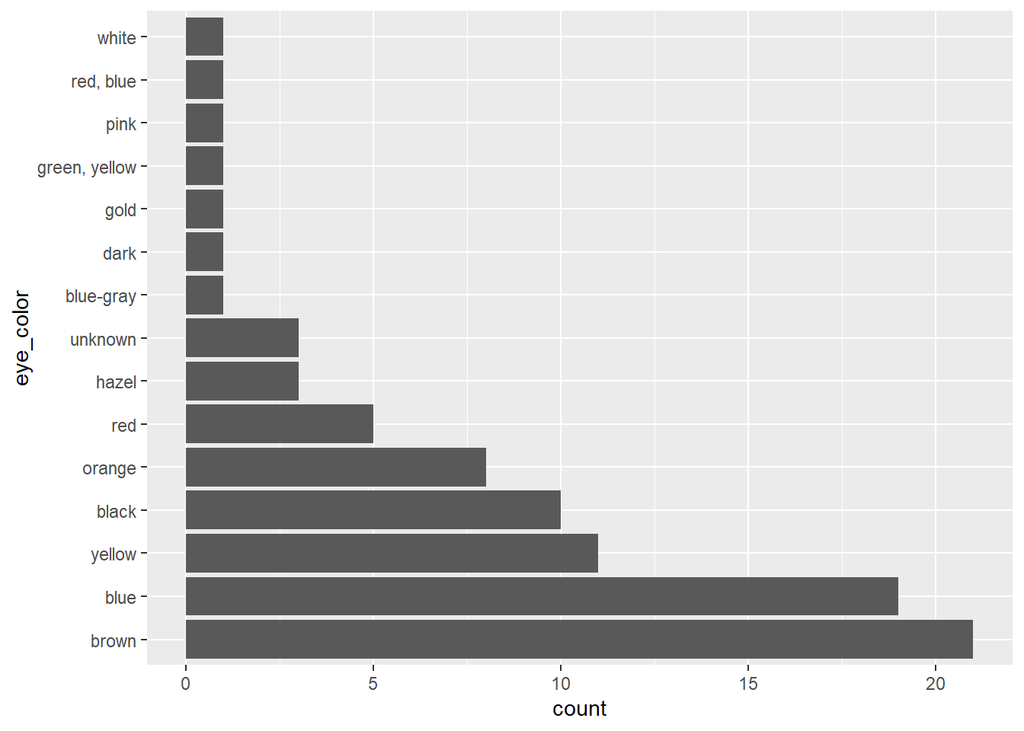

```r
starwars %>%
  mutate(eye_color = fct_infreq(eye_color)) %>%
  ggplot(aes(x = eye_color)) +
  geom_bar() +
  coord_flip()
```